# Lab 4

Jacob Baalson, Charlie Whiting GitHub: jbaalson, chrlwhtng

3/20/2020

Part One: Cleaning Data

```r
library(readxl)
defense <- read_excel('cyclonesFootball2019.xlsx', sheet='Defensive')
offense <- read_excel('cyclonesFootball2019.xlsx', sheet='Offensive')
biography <- read_excel('cyclonesFootball2019.xlsx', sheet='Biography')

library(dplyr)
library(tidyverse)
library(ggplot2)
defense <- defense %>% mutate(Name = factor(Name), Opponent_Opponent = factor(Opponent_Opponent))
offense <- offense %>% mutate(Name = factor(Name), Opponent_Opponent = factor(Opponent_Opponent))
biography <- biography %>% mutate(Name = factor(Name))
defClean <- defense %>% mutate_at(.vars = vars(Tackles_Solo, Tackles_ASST, Tackles_TFL, Tackles_Sack, Turnover_FF, Turnover_FR, Turnover_INT, Pass_QBH, Pass_PB), .funs = funs(as.numeric))
offClean <- offense %>% mutate_at(.vars = vars(Rushing_ATT, Rushing_YDS, Rushing_TD, Receiving_REC, Receiving_YDS, Receiving_TD, 'Passing_CMP-ATT', Passing_YDS, Passing_TD, Passing_INT), .funs = funs(as.numeric))
biography <- biography %>% mutate_at(.vars = vars(Weight), .funs = funs(as.numeric))
bioClean <- biography %>% separate(col = Height, into= c('Feet', 'Inches'), sep = "-") %>% mutate_at(.vars = vars(Feet, Inches), .funs = funs(as.numeric)) %>% mutate(Feet = Feet* 12) %>% mutate(Height_Inches = Feet + Inches) %>% select(-Inches, -Feet)
str(bioClean)
```

```
## Classes 'tbl_df', 'tbl' and 'data.frame':    105 obs. of  7 variables:
##  $ Name         : Factor w/ 105 levels "Akers, Landen",..: 1 2 3 4 5 6 7 8 9 10 ...
##  $ Position     : chr  "Wide Receiver" "Tight End" "Wide Receiver" "Placekicker" ...
##  $ Weight       : num  188 245 204 195 190 235 255 285 300 215 ...
##  $ Class        : chr  "Redshirt Senior" "Redshirt Senior" "Redshirt Freshman" "Redshirt Senior" ...
##  $ Hometown     : chr  "Cedar Rapids, Iowa" "Nixa, Mo." "Seffner, Fla." "Naperville, Ill." ...
##  $ Highschool   : chr  "Washington" "Nixa" "Armwood" "Central" ...
##  $ Height_Inches: num  72 79 77 72 72 75 74 74 72 78 ...
```

```r
str(defClean)
```

```
## Classes 'tbl_df', 'tbl' and 'data.frame':    502 obs. of  11 variables:
##  $ Name             : Factor w/ 43 levels "Akers, Landen",..: 40 40 40 40 40 40 40 40 40 40 ...
##  $ Opponent_Opponent: Factor w/ 13 levels "Baylor","Iowa",..: 12 2 11 1 8 13 10 7 6 9 ...
##  $ Tackles_Solo     : num  4 4 3 4 3 1 7 3 6 5 ...
##  $ Tackles_ASST     : num  4 7 5 2 2 1 1 2 1 5 ...
##  $ Tackles_TFL      : num  0 0 0 0 1 0 0 0 1 1 ...
##  $ Tackles_Sack     : num  0 0 0 0 0 0 0 0 0 1 ...
##  $ Turnover_FF      : num  0 0 0 0 0 0 0 0 0 0 ...
##  $ Turnover_FR      : num  0 0 0 0 0 0 0 0 0 0 ...
##  $ Turnover_INT     : num  0 0 1 0 0 0 0 0 1 0 ...
##  $ Pass_QBH         : num  1 0 0 0 0 0 0 0 1 0 ...
##  $ Pass_PB          : num  1 2 0 0 0 1 0 0 0 0 ...
```

```r
str(offClean)
```

```
## Classes 'tbl_df', 'tbl' and 'data.frame':    195 obs. of  12 variables:
##  $ Name             : Factor w/ 17 levels "Akers, Landen",..: 1 1 1 1 1 1 1 1 1 1 ...
##  $ Opponent_Opponent: Factor w/ 13 levels "Baylor","Iowa",..: 12 2 11 1 8 13 10 7 6 9 ...
##  $ Rushing_ATT      : num  0 0 1 0 0 0 0 0 0 0 ...
##  $ Rushing_YDS      : num  0 0 8 0 0 0 0 0 0 0 ...
##  $ Rushing_TD       : num  0 0 0 0 0 0 0 0 0 0 ...
##  $ Receiving_REC    : num  1 0 0 0 1 0 0 4 0 1 ...
##  $ Receiving_YDS    : num  21 0 0 0 32 0 0 39 0 7 ...
##  $ Receiving_TD     : num  0 0 0 0 0 0 0 0 0 0 ...
##  $ Passing_CMP-ATT  : num  NA NA NA NA NA NA NA NA NA NA ...
##  $ Passing_YDS      : num  NA NA NA NA NA NA NA NA NA NA ...
##  $ Passing_TD       : num  NA NA NA NA NA NA NA NA NA NA ...
##  $ Passing_INT      : num  NA NA NA NA NA NA NA NA NA NA ...
```

Part Two: Tidying

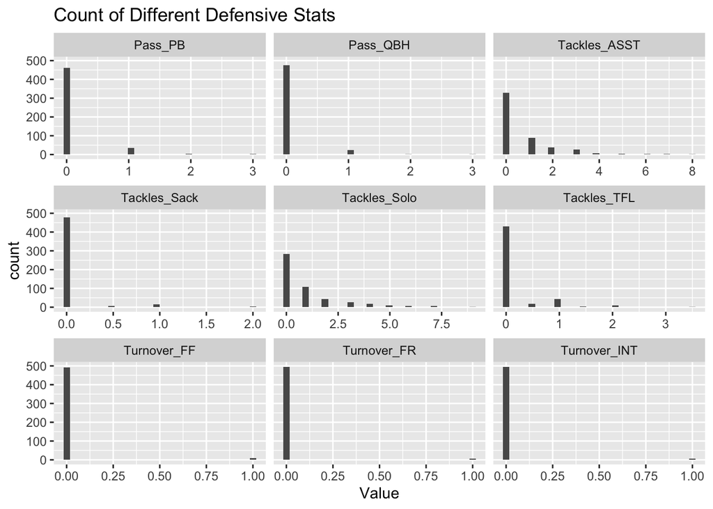

```r
defClean <- defClean %>% pivot_longer(Tackles_Solo:Pass_PB, names_to = 'Statistic', values_to = 'Value')
#View(defClean)
defClean %>% ggplot(aes(x = Value)) + geom_histogram() + facet_wrap(~Statistic, scales = 'free_x') + ggtitle("Count of Different Defensive Stats")
```

The Rarest defensive skills are forced fumbles, fumble recoveries, and interceptions. This is because for most players those values are at zero and only a few players have 1 of these statistics.

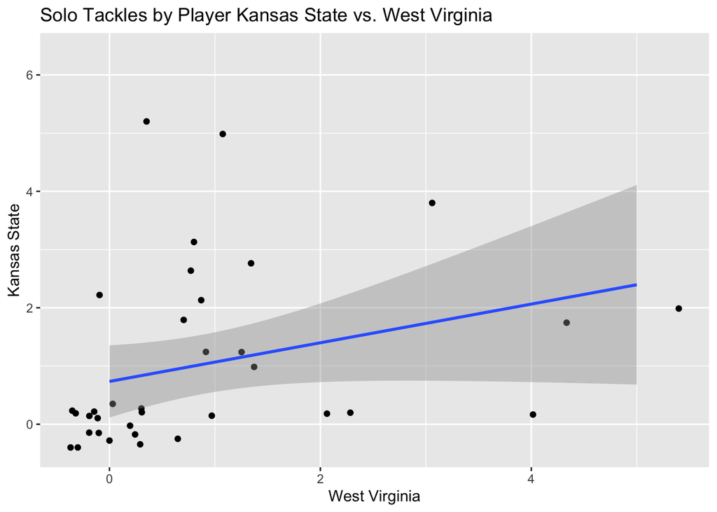

```r
def <- defClean
def$Value <- def$Value %>% replace_na(0)
def <- def %>% filter(Statistic == "Tackles_Solo", Opponent_Opponent %in% c('West Virginia', 'Kansas State'))
def <- def %>% pivot_wider(names_from = Opponent_Opponent, values_from = Value)
def %>% ggplot(aes(x = `West Virginia`, y = `Kansas State`)) + geom_point(position = 'jitter') + geom_smooth(method = lm) + ggtitle("Solo Tackles by Player Kansas State vs. West Virginia")
```

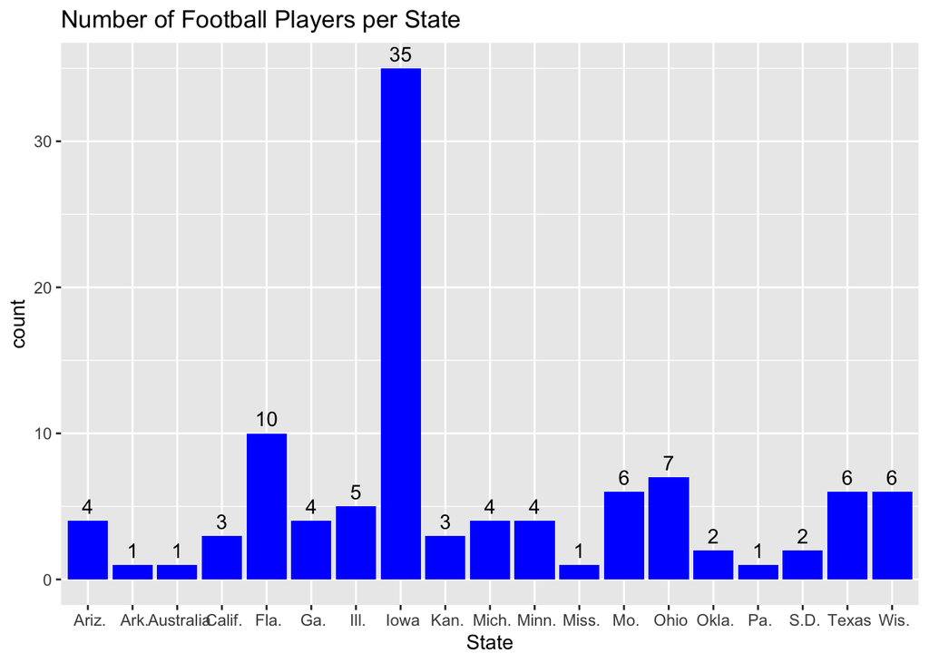

```r
bioClean <- bioClean %>% separate(col=Hometown, into=c("City", "State"), sep=',')

bioClean %>% ggplot(aes(x=State)) + geom_bar(fill='blue') +
  geom_text(stat='count', aes(label=stat(count), vjust = -.5)) +
  ggtitle("Number of Football Players per State")
```

From this graph, it is clear that Iowa is the home state containing the most Iowa State University Football players. This is followed by Florida and Ohio.

Part Three: Joining Data Frames

```r
#One row per player, not per game.
offPlayers <- offClean %>% pivot_wider(names_from = "Opponent_Opponent", values_from = Rushing_ATT:Passing_INT)

offHome <- bioClean %>% inner_join(offPlayers) %>% group_by(Name)
```

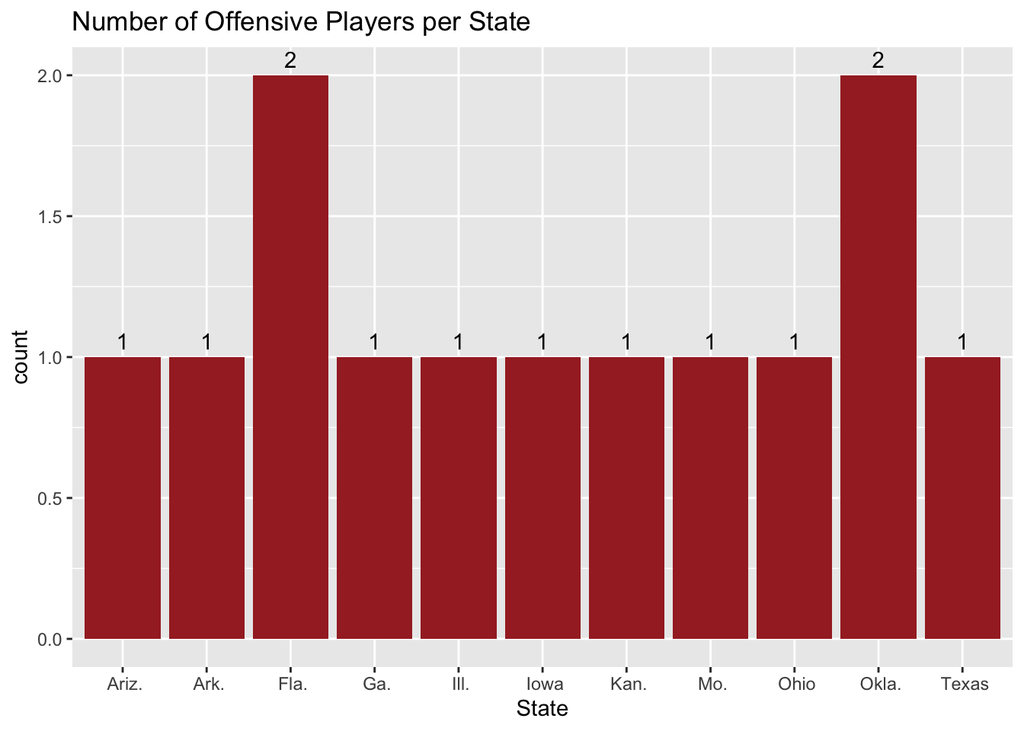

```r
offHome %>% ggplot(aes(x=State)) + geom_bar(fill='brown') +
  ggtitle("Number of Offensive Players per State") +
  geom_text(stat='count', aes(label=stat(count), vjust = -.5))
```

This graph shows that Florida and Oklahoma are both home to 2 offensive players, and that every other state only is home to one player.

```r
weightReceiving <- bioClean %>% inner_join(offClean)
```

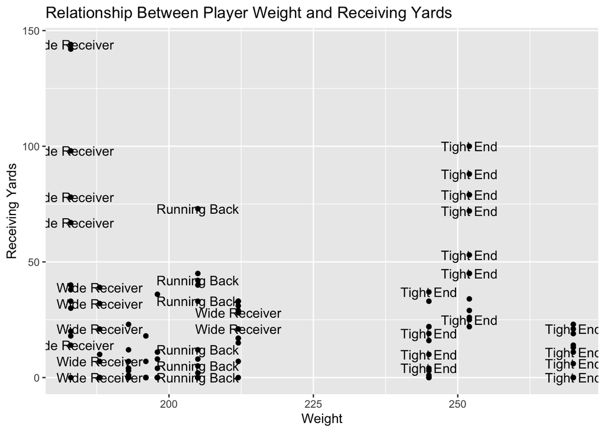

```r
weightReceiving %>% ggplot(aes(x=Weight, y=Receiving_YDS)) +
  geom_point() + ylab("Receiving Yards") +
  ggtitle("Relationship Between Player Weight and Receiving Yards") +
  geom_text(label=weightReceiving$Position, check_overlap = TRUE)
```

This is a difficult question to answer. It is easy to see that each vertical line represents one player, with each point representing a specific game they played during the season. I added the detail of what position this player plays into the plot. I don’t think weight matters when determining relationship on receiving yards as much as position, for example, as the running backs plotted above tend to have less receiving yards than the wide receivers or tight ends do. If there is a relationship between weight and receiving yards, it likely comes from the average weight that comes with each position, as inemen weigh much more than wide receivers.

```r
#Create a dataframe containing offensive stats unrelating to QB play (rushing) and defensive tackles/INTs
def <- defClean %>% pivot_wider(names_from = Statistic, values_from = Value) %>%
  select(Name, Opponent_Opponent, Turnover_INT, Tackles_Solo)
off <- offClean %>% select(Name, Opponent_Opponent, Rushing_TD, Rushing_YDS, Passing_YDS, Passing_TD, Passing_INT)

cyclones <- full_join(off, def)
```

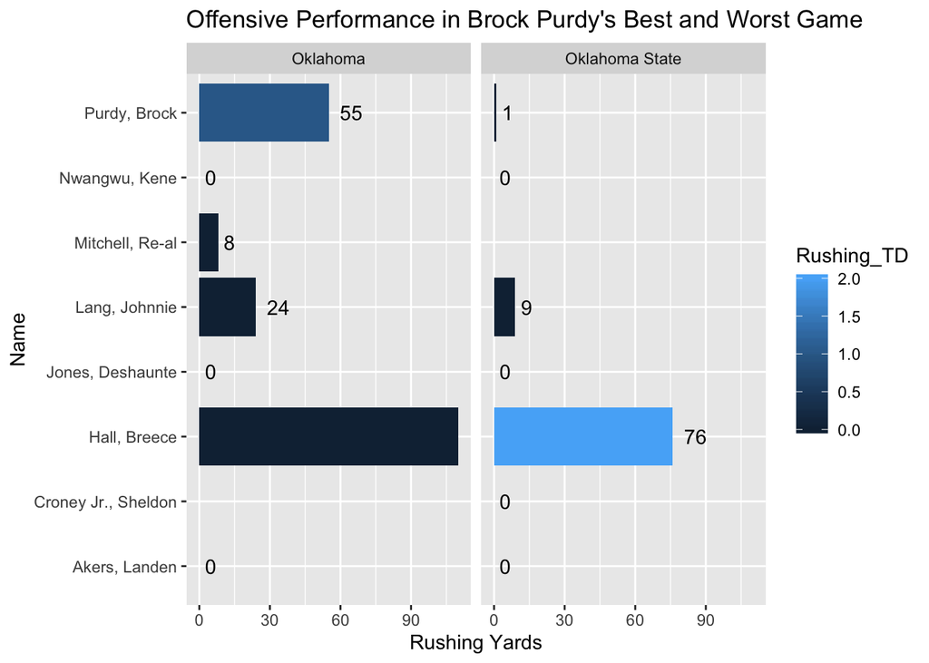

```r
brockPurdy <- cyclones %>% filter(Name == 'Purdy, Brock') %>%
  select(Name, Opponent_Opponent, Passing_YDS, Passing_TD, Passing_INT)

brockBest <- brockPurdy %>% filter(Passing_TD == max(brockPurdy$Passing_TD))
brockWorst <- brockPurdy %>% filter(Passing_INT == max(brockPurdy$Passing_INT))

bestGame <- brockBest$Opponent_Opponent #Oklahoma: 5 TDs
worstGame <- brockWorst$Opponent_Opponent #Oklahoma State: 3 INTs

cyclones <- cyclones %>%
  filter(Opponent_Opponent == bestGame | Opponent_Opponent == worstGame)

cyclones %>% filter(!is.na(Rushing_YDS)) %>%
  ggplot(aes(x=Name, weight=Rushing_YDS, fill=Rushing_TD)) + geom_bar() +  coord_flip() +
  facet_wrap(~Opponent_Opponent) +
  geom_text(stat='count', aes(label=stat(count), hjust = -.5)) +
  ylab("Rushing Yards") + ggtitle("Offensive Performance in Brock Purdy's Best and Worst Game")
```

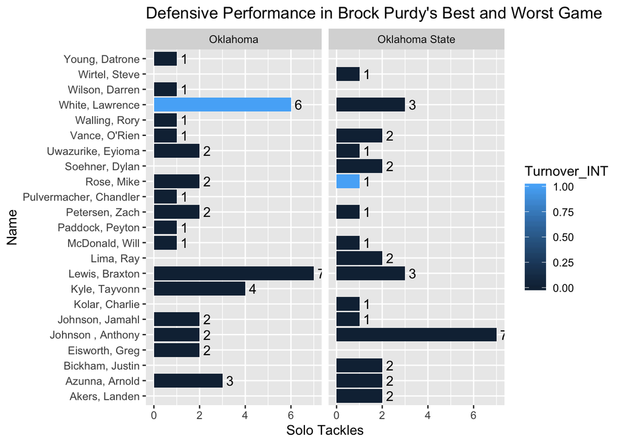

```r
cyclones %>% filter(Tackles_Solo != 0) %>%
  ggplot(aes(x=Name, weight=Tackles_Solo, fill=Turnover_INT)) + geom_bar() +
  coord_flip() + facet_wrap(~Opponent_Opponent) +
  geom_text(stat='count', aes(label=stat(count), hjust = -.5)) +
  ylab("Solo Tackles") + ggtitle("Defensive Performance in Brock Purdy's Best and Worst Game")
```

These plots show how the football team played during Brock’s best (Oklahoma) and worst (Oklahoma State) game of the season. It makes sense that a good game for Brock translated to a good run game, since it appears the mix of running and passing kept the defense off balance and kept both options fresh. It also makes sense that a bad passing game for Brock translated to lower rushing yards. This is likely due to the Cyclones playing against a very strong defense.

On the defensive side of the ball, it appeared that the Cyclones played relatively similar football. Both games had one or two standout performances, but the rest of the team seemed to play at relatively similar level. This graph/dataset does not account for time of possession for each team, so it is impossible to know how quickly or slowly these stats were accrued. If the defense in one of these games was on the field for twice the amount of the other one, it would make sense to conclude that that defensive showing wasn’t as strong as the other. But, with the given information, it appears that the overall defensive play by the Cyclones was consistent between the two games.

Does performance of the defense(Tackles) affect performance of the offense(Total_TDs), and did this change from 2018 to 2019?

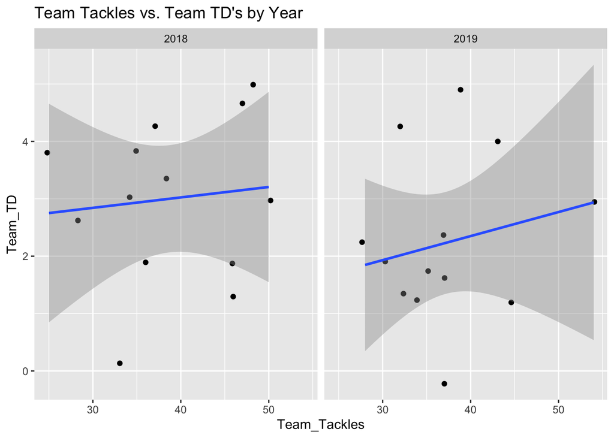

```r
defense18 <- read_excel('cyclonesFootball2018.xlsx', sheet='Defensive')
offense18 <- read_excel('cyclonesFootball2018.xlsx', sheet='Offensive')
biography18 <- read_excel('cyclonesFootball2018.xlsx', sheet='Biography')
defense18 <- defense18 %>% mutate(Name = factor(Name), Opponent_Opponent = factor(Opponent_Opponent))
offense18 <- offense18 %>% mutate(Name = factor(Name), Opponent_Opponent = factor(Opponent_Opponent))
biography18 <- biography18 %>% mutate(Name = factor(Name))
defClean18 <- defense18 %>% mutate_at(.vars = vars(Tackles_Solo, Tackles_ASST, Tackles_TFL, Tackles_Sack, Turnover_FF, Turnover_FR, Turnover_INT, Pass_QBH, Pass_PB), .funs = funs(as.numeric))
offClean18 <- offense18 %>% mutate_at(.vars = vars(Rushing_ATT, Rushing_YDS, Rushing_TD, Receiving_REC, Receiving_YDS, Receiving_TD, 'Passing_CMP-ATT', Passing_YDS, Passing_TD, Passing_INT), .funs = funs(as.numeric))
biography18 <- biography18 %>% mutate_at(.vars = vars(Weight), .funs = funs(as.numeric))
bioClean18 <- biography18 %>% separate(col = Height, into= c('Feet', 'Inches'), sep = "-") %>% mutate_at(.vars = vars(Feet, Inches), .funs = funs(as.numeric)) %>% mutate(Feet = Feet* 12) %>% mutate(Height_Inches = Feet + Inches) %>% select(-Inches, -Feet)


defClean18 <- defClean18 %>% pivot_longer(Tackles_Solo:Pass_PB, names_to = 'Statistic', values_to = 'Value')
offClean18 <- offClean18 %>% pivot_longer(Receiving_REC:Passing_INT, names_to = 'Statistic', values_to = 'Value')
offClean <- offClean %>% pivot_longer(Receiving_REC:Passing_INT, names_to= 'Statistic', values_to = 'Value')
#First make total touchdowns per game statistic and make a total tackles per game statistic and then merge the two data frames for both 2018 and 2019

defClean18 <- defClean18 %>% filter(Statistic == 'Tackles_Solo') %>% group_by(Opponent_Opponent) %>% mutate(Team_Tackles = sum(Value)) %>% ungroup
                                                                                                                            offClean18 <- offClean18 %>% filter(Statistic %in% c('Receiving_TD', 'Rushing_TD')) %>% group_by(Opponent_Opponent) %>% mutate(Team_TD = sum(Value, na.rm = TRUE))

                                                                                                                            offClean <- offClean %>% filter(Statistic %in% c('Receiving_TD', 'Rushing_TD')) %>% group_by(Opponent_Opponent) %>% mutate(Team_TD = sum(Value, na.rm = TRUE))

defClean <- defClean %>% filter(Statistic == 'Tackles_Solo') %>% group_by(Opponent_Opponent) %>% mutate(Team_Tackles = sum(Value)) %>% ungroup

                                                                                                                            both18 <- inner_join(offClean18, defClean18, by = 'Opponent_Opponent') %>% select(Opponent_Opponent, Team_Tackles, Team_TD) %>% unique() %>% mutate(year = 2018)


both19 <- inner_join(offClean, defClean, by = 'Opponent_Opponent') %>% select(Opponent_Opponent, Team_Tackles, Team_TD) %>% unique() %>% mutate(year = 2019)


both <- full_join(both18, both19)
both %>% ggplot(aes(x= Team_Tackles, y = Team_TD)) + geom_point(position = "jitter") + facet_wrap(~year) + geom_smooth(method = lm) + ggtitle("Team Tackles vs. Team TD's by Year")
```